# HW 1

## Setup

```python
# To support both python 2 and python 3
from __future__ import division, print_function, unicode_literals

# We need to import key libraries that we're going to use.
# For now this is just numpy, which is our linear algebra library
import numpy as np
```

```python
# to make this notebook's output stable across runs, we are going to see the random seed
np.random.seed(42)
```

```python
# To plot pretty figures
import matplotlib.pyplot as plt
%matplotlib inline
# This command figures show up in the notebook.  It's a "magic" command...
# Typically, this now happens by default so it is often an unnecessary command, but is good for standardization.
plt.rcParams['axes.labelsize'] = 14
plt.rcParams['xtick.labelsize'] = 12
plt.rcParams['ytick.labelsize'] = 12
```

```python
# Where to save the figures
PROJECT_ROOT_DIR = "."
PROJECT_SAVE_DIR = "hw1"
```

```python
# makes the directory if it doesn't exist.
import os
if not (os.path.isdir(PROJECT_ROOT_DIR+'/'+PROJECT_SAVE_DIR)):
    print('Figure directory didn\'t exist, creating now.')
    os.mkdir(PROJECT_ROOT_DIR+'/'+PROJECT_SAVE_DIR)
else:
    print('Figure directory exists.')
```

```
Figure directory exists.
```

```python
# a simple defined helper function.
def savepdf(fig,name):
    fig.savefig(PROJECT_ROOT_DIR+'/'+PROJECT_SAVE_DIR+'/'+name+'.pdf')
```

# Problem 3

## Data For Specific Problesm

```python
## Code to save to csv, if desired.
import pandas as pd
```

**Problem 3(a)**: 1-d test scores for pass/fail

```python
# Here is a function that generates data of students taking a test.  It's just like the real thing!
def generate_students_pass_fail(n=300,pass_line=75,random_seed=42):
    def sigmoid(x):
        return 1./(1.+np.exp(-x))
    # Generates noisy data along curved line.
    # The curve is non-linear and the noise/variance is heteroskedastic and non-gaussian, so it breaks
    # pretty much all classical statistical model assumptions.  It's both pretty fun and kind of
    # disturbing how easy it is to do that.
    np.random.seed(random_seed)
    x = 6*np.random.rand(n, 1)
    x = np.sort(x,axis=0)
    score = 100* sigmoid(-2+x+.4*np.random.randn(n,1))+5*np.random.randn(n,1)
    y=score>pass_line
    y=y.reshape(-1)
    return x,y
```

```python
x,y=generate_students_pass_fail()
```

```python
print(len(x))
print(len(y))
```

```
300
300
```

```python
# Save to csv if desired
df=pd.DataFrame(data=np.concatenate((x,y.reshape(-1,1)),axis=1))
df.columns=['x','y']
df[:5]
df.to_csv('hw1/3a')
```

```python
X = df['x']
Y = df['y']
```

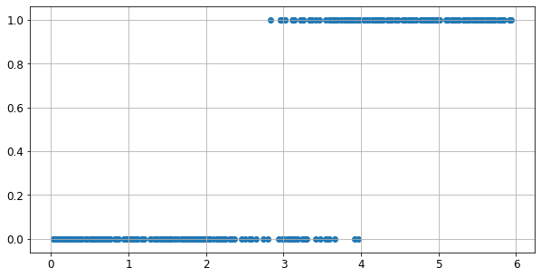

```python
plt.figure(figsize = (10, 5))
plt.scatter(X, Y)
plt.grid('on')
plt.show()
```

### i. Based on the plot above, the y values are either 0 or 1, meaning that it's a set of binary data.

```python
from sklearn.linear_model import LogisticRegression

logisticregressor = LogisticRegression()
Xre = np.array(X).reshape(-1, 1)
Yre = np.array(Y).reshape(-1 ,1).ravel()
print(Xre.shape)
print(Yre.shape)
logisticregressor.fit(Xre, Yre)
```

```
(300, 1)
(300,)
```

```
LogisticRegression(C=1.0, class_weight=None, dual=False, fit_intercept=True,
                   intercept_scaling=1, l1_ratio=None, max_iter=100,
                   multi_class='auto', n_jobs=None, penalty='l2',
                   random_state=None, solver='lbfgs', tol=0.0001, verbose=0,
                   warm_start=False)
```

```python
np.random.seed(42)

#number of data
n = 300
n_train = int(n * 0.6)
n_valid = int(n * 0.4)

X = np.array(X)
Y = np.array(Y)
```

```python
permutation=np.random.permutation(n)
x_permute=X[permutation]
y_permute=Y[permutation]
```

```python
x_train=x_permute[:n_train]
x_valid=x_permute[n_train:n_train+n_valid]
y_train=y_permute[:n_train]
y_valid=y_permute[n_train:n_train+n_valid]
```

```python
from sklearn.linear_model import LogisticRegression

logisticregressor = LogisticRegression()
logisticregressor.fit(x_train.reshape(-1, 1), y_train.ravel())
```

```
LogisticRegression(C=1.0, class_weight=None, dual=False, fit_intercept=True,
                   intercept_scaling=1, l1_ratio=None, max_iter=100,
                   multi_class='auto', n_jobs=None, penalty='l2',
                   random_state=None, solver='lbfgs', tol=0.0001, verbose=0,
                   warm_start=False)
```

```python
print(y_train.shape)
print(y_valid.shape)
```

```
(180,)
(120,)
```

```python
from sklearn.metrics import mean_squared_error
from sklearn.metrics import accuracy_score

#logistic_training_mse=mean_squared_error(y_train.reshape(-1, 1),logisticregressor.predict(x_train.reshape(-1, 1)))
#logistic_valid_mse=mean_squared_error(y_valid.reshape(-1, 1),logisticregressor.predict(x_valid.reshape(-1, 1)))

#logisticregressor_predict_prob =  logisticregressor.predict_proba(x_train.reshape(n_train, 1))[:, 1]

logistic_training_acc=accuracy_score(y_train.reshape(-1, 1),logisticregressor.predict(x_train.reshape(-1, 1)))
logistic_valid_acc=accuracy_score(y_valid.reshape(-1, 1),logisticregressor.predict(x_valid.reshape(-1, 1)))

#logistic_training_mse=mean_squared_error(y_train.reshape(-1, 1),logisticregressor.predict_proba(x_train.reshape(n_train, 1))[:, 1])
#logistic_valid_mse=mean_squared_error(y_valid.reshape(-1, 1),logisticregressor.predict_proba(x_valid.reshape(n_valid, 1))[:, 1])
```

```python
print(str(logistic_training_acc)+', '+ str(logistic_valid_acc))
print(str(1- logistic_training_acc)+', '+ str(1 - logistic_valid_acc))
```

```
0.9222222222222223, 0.9333333333333333
0.07777777777777772, 0.06666666666666665
```

```python
#print(str(logistic_training_mse)+', '+ str(logistic_valid_mse))
```

### ii. The validation accuracy is around 93.333%, and the error is around 6.667%.

```python
from sklearn.neighbors import KNeighborsClassifier
from sklearn.neighbors import KNeighborsRegressor

MSE = list()
ACC = list()
for k in range(1,30):
    knnmodel=KNeighborsClassifier(n_neighbors=k)
    knnmodel.fit(x_train.reshape(-1, 1),y_train.reshape(-1, 1).ravel())
    #knn_valid_mse=mean_squared_error(y_valid.reshape(-1, 1),knnmodel.predict(x_valid.reshape(-1, 1)))
    knn_valid_acc=accuracy_score(y_valid.reshape(-1, 1),knnmodel.predict(x_valid.reshape(-1, 1)))
    #print('For {} neighbors the validation MSE is {}'.format(k,knn_valid_mse))
    print('For {} neighbors the validation ACC is {}'.format(k,knn_valid_acc))
    ACC.append(knn_valid_acc)
    #MSE.append(knn_valid_mse)
#print('Within k from 1 to 29, the optimal number of k is:', MSE.index(np.min(MSE)) + 1, '\nAnd the corresponding MSE is:', np.min(MSE))
print('Within k from 1 to 29, the optimal number of k is:', ACC.index(np.max(ACC)) + 1, '\nAnd the corresponding ACC is:', np.max(ACC))
print('And the error is: ', 1 - np.max(ACC))
```

```
For 1 neighbors the validation ACC is 0.925
For 2 neighbors the validation ACC is 0.925
For 3 neighbors the validation ACC is 0.95
For 4 neighbors the validation ACC is 0.9333333333333333
For 5 neighbors the validation ACC is 0.9166666666666666
For 6 neighbors the validation ACC is 0.9166666666666666
For 7 neighbors the validation ACC is 0.925
For 8 neighbors the validation ACC is 0.9083333333333333
For 9 neighbors the validation ACC is 0.9333333333333333
For 10 neighbors the validation ACC is 0.9083333333333333
For 11 neighbors the validation ACC is 0.9166666666666666
For 12 neighbors the validation ACC is 0.9166666666666666
For 13 neighbors the validation ACC is 0.925
For 14 neighbors the validation ACC is 0.9166666666666666
For 15 neighbors the validation ACC is 0.925
For 16 neighbors the validation ACC is 0.9166666666666666
For 17 neighbors the validation ACC is 0.925
For 18 neighbors the validation ACC is 0.9166666666666666
For 19 neighbors the validation ACC is 0.9166666666666666
For 20 neighbors the validation ACC is 0.9166666666666666
For 21 neighbors the validation ACC is 0.925
For 22 neighbors the validation ACC is 0.9166666666666666
For 23 neighbors the validation ACC is 0.925
For 24 neighbors the validation ACC is 0.925
For 25 neighbors the validation ACC is 0.925
For 26 neighbors the validation ACC is 0.925
For 27 neighbors the validation ACC is 0.9333333333333333
For 28 neighbors the validation ACC is 0.9333333333333333
For 29 neighbors the validation ACC is 0.9333333333333333
Within k from 1 to 29, the optimal number of k is: 3
And the corresponding ACC is: 0.95
And the error is %d 0.050000000000000044
```

### iii. The best validation accuracy is around 95%, which occurs at k = 3, and the error is around 5%.

```python
test = X.reshape(300, 1)
print(test.shape)
```

```
(300, 1)
```

```python
knnmodel=KNeighborsClassifier(n_neighbors=3)
knnmodel.fit(x_train.reshape(-1, 1),y_train.reshape(-1, 1).ravel())

logistic_yhat = logisticregressor.predict(X.reshape(-1, 1))
temp = logisticregressor.predict_proba(test)
knn_yhat = knnmodel.predict(X.reshape(-1, 1))
logistic_yhat_proba = list()
for row in temp:
    logistic_yhat_proba.append(row[1])
logistic_yhat_proba =  np.array(logistic_yhat_proba)
```

```python
logistic_yhat_proba = logisticregressor.predict_proba(X.reshape(300, 1))[:, 1]
print(type(temp))
print(temp.shape)
```

```
<class 'numpy.ndarray'>
(300, 2)
```

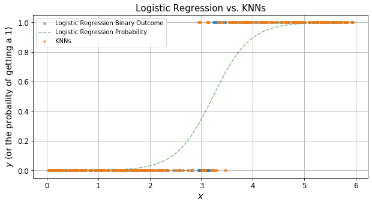

```python
plt.figure(figsize = (10, 5))
plt.plot(X, logistic_yhat, 'o', alpha = 0.5, markersize = 4, label = 'Logistic Regression Binary Outcome')
plt.plot(X, logistic_yhat_proba, 'g--', alpha = 0.5, markersize = 5, label = 'Logistic Regression Probability')
plt.plot(X, knn_yhat, 'o', alpha = 0.5, markersize = 4, label = 'KNNs')
plt.grid('on')
plt.title('Logistic Regression vs. KNNs', size = 15)
plt.xlabel("$x$")
plt.ylabel("$y$ (or the probaility of getting a 1)")
plt.legend()
plt.show()
```

### v. I prefer the KNNs model because it yields a smaller MSE, which means the results coming out of it would be considered more reliable compared to that of the Logistic Regression model. However, if we want to explicitly know the probabilities of each x value being classified as 1, we may want to consider using the logistic regression model.

**Problem 3(b)**: 2-d circles

```python
from sklearn.datasets import make_circles
x,y=make_circles(n_samples=700,shuffle=False,noise=.08,random_state=42)
```

```python
# Save to csv if desired
df=pd.DataFrame(data=np.concatenate((x,y.reshape(-1,1)),axis=1))
df.columns=['x1','x2','y']
df[:5]
df.to_csv('hw1/3b')
print(df[:5])
```

```
         x1        x2    y
0  1.039737 -0.011061  0.0
1  1.051654  0.139793  0.0
2  0.980623  0.017165  0.0
3  1.124887  0.115225  0.0
4  0.959865  0.115151  0.0
```

```python
x1 = np.array(df['x1'])
x2 = np.array(df['x2'])
y = np.array(df['y'])
print(x1.shape, x2.shape, y.shape)
```

```
(700,) (700,) (700,)
```

```python
position = []
for i in range(len(x1)):
    temp = []
    temp.append(np.array(x1[i]))
    temp.append(np.array(x2[i]))
    position.append(np.array(temp))
position = np.array(position)
print(position.shape)
print(y.shape)
```

```
(700, 2)
(700,)
```

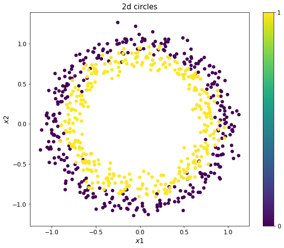

```python
plt.figure(figsize = (10, 8))
plt.scatter(position[:,0], position[:,1], c = y)
plt.colorbar(ticks = [0, 1])
plt.xlabel("$x1$")
plt.ylabel("$x2$")
plt.title('2d circles', size = 15)
plt.show()
```

```python
np.random.seed(42)

#number of data
n = 700
n_train = int(n * 0.6)
n_valid = int(n * 0.4)

X = df[['x1', 'x2']].to_numpy()
Y = df['y'].to_numpy()
```

```python
permutation=np.random.permutation(n)
x_permute=X[permutation]
y_permute=Y[permutation]
```

```python
x_train=x_permute[:n_train]
x_valid=x_permute[n_train:n_train+n_valid]
y_train=y_permute[:n_train]
y_valid=y_permute[n_train:n_train+n_valid]
```

```python
logisticregressor = LogisticRegression()
logisticregressor.fit(x_train, y_train)
```

```
LogisticRegression(C=1.0, class_weight=None, dual=False, fit_intercept=True,
                   intercept_scaling=1, l1_ratio=None, max_iter=100,
                   multi_class='auto', n_jobs=None, penalty='l2',
                   random_state=None, solver='lbfgs', tol=0.0001, verbose=0,
                   warm_start=False)
```

```python
#logistic_training_mse=mean_squared_error(y_train.reshape(-1, 1),logisticregressor.predict(x_train.reshape(-1, 2)))
#logistic_valid_mse=mean_squared_error(y_valid.reshape(-1, 1),logisticregressor.predict(x_valid.reshape(-1, 2)))

#logistic_training_mse=mean_squared_error(y_train.reshape(-1, 1),logisticregressor.predict_proba(x_train.reshape(n_train, 2))[:, 1])
#logistic_valid_mse=mean_squared_error(y_valid.reshape(-1, 1),logisticregressor.predict_proba(x_valid.reshape(n_valid, 2))[:, 1])

logistic_training_acc=accuracy_score(y_train.reshape(-1, 1),logisticregressor.predict(x_train.reshape(-1, 2)))
logistic_valid_acc=accuracy_score(y_valid.reshape(-1, 1),logisticregressor.predict(x_valid.reshape(-1, 2)))
```

```python
#print(str(logistic_training_mse)+', '+ str(logistic_valid_mse))
print(str(logistic_training_acc)+', '+ str(logistic_valid_acc))
print(str(1 - logistic_training_acc)+', '+ str(1 - logistic_valid_acc))
```

```
0.5357142857142857, 0.44642857142857145
0.4642857142857143, 0.5535714285714286
```

### ii. The validation accuracy is 44.643%, and the error is around 55.357%.

```python
ACC = list()
for k in range(1,30):
    knnmodel=KNeighborsClassifier(n_neighbors=k)
    knnmodel.fit(x_train,y_train)
    knn_valid_acc=accuracy_score(y_valid.reshape(-1, 1),knnmodel.predict(x_valid.reshape(-1, 2)))
    print('For {} neighbors the validation ACC is {}'.format(k,knn_valid_acc))
    ACC.append(knn_valid_acc)
print('Within k from 1 to 29, the optimal number of k is:', ACC.index(np.max(ACC)) + 1, '\nAnd the corresponding ACC is:', np.max(ACC))
print('And the error is: ', 1 - np.max(ACC))
```

```
For 1 neighbors the validation ACC is 0.875
For 2 neighbors the validation ACC is 0.8464285714285714
For 3 neighbors the validation ACC is 0.8928571428571429
For 4 neighbors the validation ACC is 0.8714285714285714
For 5 neighbors the validation ACC is 0.9071428571428571
For 6 neighbors the validation ACC is 0.8928571428571429
For 7 neighbors the validation ACC is 0.9035714285714286
For 8 neighbors the validation ACC is 0.8928571428571429
For 9 neighbors the validation ACC is 0.8964285714285715
For 10 neighbors the validation ACC is 0.8964285714285715
For 11 neighbors the validation ACC is 0.8928571428571429
For 12 neighbors the validation ACC is 0.8785714285714286
For 13 neighbors the validation ACC is 0.8821428571428571
For 14 neighbors the validation ACC is 0.8857142857142857
For 15 neighbors the validation ACC is 0.9071428571428571
For 16 neighbors the validation ACC is 0.8928571428571429
For 17 neighbors the validation ACC is 0.8964285714285715
For 18 neighbors the validation ACC is 0.8928571428571429
For 19 neighbors the validation ACC is 0.8928571428571429
For 20 neighbors the validation ACC is 0.8857142857142857
For 21 neighbors the validation ACC is 0.8857142857142857
For 22 neighbors the validation ACC is 0.875
For 23 neighbors the validation ACC is 0.8857142857142857
For 24 neighbors the validation ACC is 0.8678571428571429
For 25 neighbors the validation ACC is 0.8642857142857143
For 26 neighbors the validation ACC is 0.8642857142857143
For 27 neighbors the validation ACC is 0.8678571428571429
For 28 neighbors the validation ACC is 0.8642857142857143
For 29 neighbors the validation ACC is 0.8642857142857143
Within k from 1 to 29, the optimal number of k is: 5
And the corresponding ACC is: 0.9071428571428571
And the error is %d 0.09285714285714286
```

### iii. The best validation accuracy is around 90.714%, which occurs at k = 5, and the error is around 9.286%.

**Problem 3(c)**: 2-d moons

```python
from sklearn.datasets import make_moons
x,y=make_moons(n_samples=300,noise=.75,random_state=42)
```

```python
# Save to csv if desired
df=pd.DataFrame(data=np.concatenate((x,y.reshape(-1,1)),axis=1))
df.columns=['x1','x2','y']
df[:5]
df.to_csv('hw1/3c')
print(df[:5])
```

```
         x1        x2    y
0  1.469087  0.004471  1.0
1  3.818365 -0.070667  1.0
2 -1.053915  0.431946  1.0
3  0.259788  0.921509  0.0
4  1.209746 -0.586937  1.0
```

```python
x1 = np.array(df['x1'])
x2 = np.array(df['x2'])
y = np.array(df['y'])
print(x1.shape, x2.shape, y.shape)
```

```
(300,) (300,) (300,)
```

```python
position = []
for i in range(len(x1)):
    temp = []
    temp.append(np.array(x1[i]))
    temp.append(np.array(x2[i]))
    position.append(np.array(temp))
position = np.array(position)
print(position.shape)
print(y.shape)
```

```
(300, 2)
(300,)
```

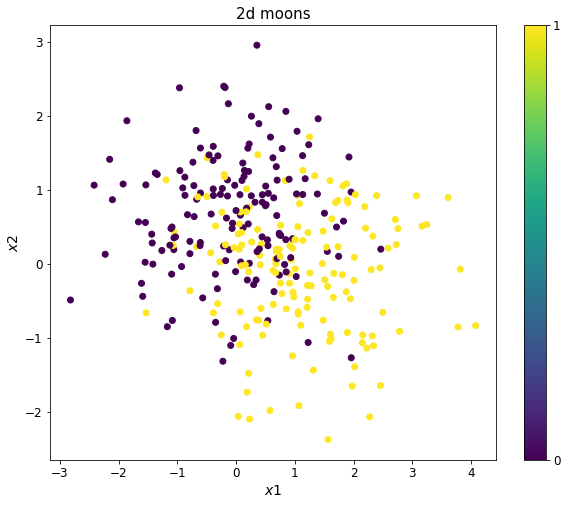

```python
plt.figure(figsize = (10, 8))
plt.scatter(position[:,0], position[:,1], c = y)
plt.colorbar(ticks = [0, 1])
plt.xlabel("$x1$")
plt.ylabel("$x2$")
plt.title('2d moons', size = 15)
plt.show()
```

```python
np.random.seed(42)

#number of data
n = 300
n_train = int(n * 0.6)
n_valid = int(n * 0.4)

X = df[['x1', 'x2']].to_numpy()
Y = df['y'].to_numpy()

permutation=np.random.permutation(n)
x_permute=X[permutation]
y_permute=Y[permutation]
```

```python
x_train=x_permute[:n_train]
x_valid=x_permute[n_train:n_train+n_valid]
y_train=y_permute[:n_train]
y_valid=y_permute[n_train:n_train+n_valid]
```

```python
print(x_train.shape)
```

```
(180, 2)
```

```python
logisticregressor = LogisticRegression()
logisticregressor.fit(x_train, y_train)
```

```
LogisticRegression(C=1.0, class_weight=None, dual=False, fit_intercept=True,
                   intercept_scaling=1, l1_ratio=None, max_iter=100,
                   multi_class='auto', n_jobs=None, penalty='l2',
                   random_state=None, solver='lbfgs', tol=0.0001, verbose=0,
                   warm_start=False)
```

```python
#logistic_training_mse=mean_squared_error(y_train.reshape(-1, 1),logisticregressor.predict(x_train.reshape(-1, 2)))
#logistic_valid_mse=mean_squared_error(y_valid.reshape(-1, 1),logisticregressor.predict(x_valid.reshape(-1, 2)))

#logistic_training_mse=mean_squared_error(y_train.reshape(-1, 1),logisticregressor.predict_proba(x_train.reshape(n_train, 2))[:, 1])
#logistic_valid_mse=mean_squared_error(y_valid.reshape(-1, 1),logisticregressor.predict_proba(x_valid.reshape(n_valid, 2))[:, 1])

logistic_training_acc=accuracy_score(y_train.reshape(-1, 1),logisticregressor.predict(x_train.reshape(-1, 2)))
logistic_valid_acc=accuracy_score(y_valid.reshape(-1, 1),logisticregressor.predict(x_valid.reshape(-1, 2)))
```

```python
print(str(logistic_training_acc)+', '+ str(logistic_valid_acc))
print(str(1 - logistic_training_acc)+', '+ str(1 - logistic_valid_acc))
```

```
0.8166666666666667, 0.6833333333333333
0.18333333333333335, 0.31666666666666665
```

### ii. The validation accuracy is around 68.333%, and the error is around 31.667%.

```python
ACC = list()
for k in range(1,30):
    knnmodel=KNeighborsClassifier(n_neighbors=k)
    knnmodel.fit(x_train,y_train)
    knn_valid_acc=accuracy_score(y_valid,knnmodel.predict(x_valid.reshape(-1, 2)))
    print('For {} neighbors the validation ACC is {}'.format(k,knn_valid_acc))
    ACC.append(knn_valid_acc)
print('Within k from 1 to 29, the optimal number of k is:', ACC.index(np.max(ACC)) + 1, '\nAnd the corresponding ACC is:', np.max(ACC))
print('And the error is: ', 1 - np.max(ACC))
```

```
For 1 neighbors the validation ACC is 0.6583333333333333
For 2 neighbors the validation ACC is 0.6666666666666666
For 3 neighbors the validation ACC is 0.6333333333333333
For 4 neighbors the validation ACC is 0.6666666666666666
For 5 neighbors the validation ACC is 0.6916666666666667
For 6 neighbors the validation ACC is 0.6666666666666666
For 7 neighbors the validation ACC is 0.6833333333333333
For 8 neighbors the validation ACC is 0.6833333333333333
For 9 neighbors the validation ACC is 0.6833333333333333
For 10 neighbors the validation ACC is 0.6916666666666667
For 11 neighbors the validation ACC is 0.6666666666666666
For 12 neighbors the validation ACC is 0.6833333333333333
For 13 neighbors the validation ACC is 0.6666666666666666
For 14 neighbors the validation ACC is 0.6666666666666666
For 15 neighbors the validation ACC is 0.675
For 16 neighbors the validation ACC is 0.65
For 17 neighbors the validation ACC is 0.6416666666666667
For 18 neighbors the validation ACC is 0.6416666666666667
For 19 neighbors the validation ACC is 0.6666666666666666
For 20 neighbors the validation ACC is 0.6666666666666666
For 21 neighbors the validation ACC is 0.6666666666666666
For 22 neighbors the validation ACC is 0.6666666666666666
For 23 neighbors the validation ACC is 0.675
For 24 neighbors the validation ACC is 0.675
For 25 neighbors the validation ACC is 0.675
For 26 neighbors the validation ACC is 0.675
For 27 neighbors the validation ACC is 0.6666666666666666
For 28 neighbors the validation ACC is 0.6583333333333333
For 29 neighbors the validation ACC is 0.6583333333333333
Within k from 1 to 29, the optimal number of k is: 5
And the corresponding ACC is: 0.6916666666666667
And the error is %d 0.30833333333333335
```

### iii. The best validation accuracy is around 69.167%, which occurs at k = 5, and the error is around 30.833%.

### iv. From the aspect of the statistic metric, I prefer the KNN model. However, as mentioned before, it we care about the probability of the outcomes, we may want to consider the logistic model. Note that both model's accuracy scores are pretty low for the case of this dataset.

# Problem 4

## Generating random split

```python
splits = list()
for i in range(5):
    np.random.seed(i)
    rand = np.random.dirichlet(np.ones(2))
    split = list()
    for thing in rand: split.append(round(thing, 2));
    splits.append(split)
```

```python
print(splits)
#First index of the sublist representing training percentage, second representing validation percentage, third test percentage.
```

```
[[0.39, 0.61], [0.3, 0.7], [0.96, 0.04], [0.39, 0.61], [0.81, 0.19]]
```

## Dataset 1

```python
# Here is a function that generates data of students taking a test.  It's just like the real thing!
def generate_students_pass_fail(n=300,pass_line=75,random_seed=42):
    def sigmoid(x):
        return 1./(1.+np.exp(-x))
    # Generates noisy data along curved line.
    # The curve is non-linear and the noise/variance is heteroskedastic and non-gaussian, so it breaks
    # pretty much all classical statistical model assumptions.  It's both pretty fun and kind of
    # disturbing how easy it is to do that.
    np.random.seed(random_seed)
    x = 6*np.random.rand(n, 1)
    x = np.sort(x,axis=0)
    score = 100* sigmoid(-2+x+.4*np.random.randn(n,1))+5*np.random.randn(n,1)
    y=score>pass_line
    y=y.reshape(-1)
    return x,y

x,y=generate_students_pass_fail()

# Save to csv if desired
df=pd.DataFrame(data=np.concatenate((x,y.reshape(-1,1)),axis=1))
df.columns=['x','y']

X = np.array(df['x'])
Y = np.array(df['y'])
```

```python
#number of data
n = 300
for i in range(5):
    n_train = int(n * splits[i][0])
    n_valid = int(n * splits[i][1])

    permutation=np.random.permutation(n)
    x_permute=X[permutation]
    y_permute=Y[permutation]

    x_train=x_permute[:n_train]
    x_valid=x_permute[n_train:n_train+n_valid]
    y_train=y_permute[:n_train]
    y_valid=y_permute[n_train:n_train+n_valid]

    ACC = list()

    for k in range(1,30):
        knnmodel=KNeighborsClassifier(n_neighbors=k)
        knnmodel.fit(x_train.reshape(-1, 1),y_train.reshape(-1, 1).ravel())
        knn_valid_acc=accuracy_score(y_valid.reshape(-1, 1),knnmodel.predict(x_valid.reshape(-1, 1)))
        #print('For {} neighbors the validation ACC is {}'.format(k,knn_valid_acc))
        ACC.append(knn_valid_acc)
    print('For the random split:', i + 1, ',within k from 1 to 29, the optimal number of k is:', ACC.index(np.max(ACC)) + 1, '\nAnd the corresponding ACC is:', np.max(ACC))
    print('And the error is: ', 1 - np.max(ACC))
```

```
For the random split: 1 ,within k from 1 to 29, the optimal number of k is: 21
And the corresponding ACC is: 0.9289617486338798
And the error is %d 0.07103825136612019
For the random split: 2 ,within k from 1 to 29, the optimal number of k is: 17
And the corresponding ACC is: 0.9285714285714286
And the error is %d 0.0714285714285714
For the random split: 3 ,within k from 1 to 29, the optimal number of k is: 1
And the corresponding ACC is: 0.9166666666666666
And the error is %d 0.08333333333333337
For the random split: 4 ,within k from 1 to 29, the optimal number of k is: 1
And the corresponding ACC is: 0.9344262295081968
And the error is %d 0.06557377049180324
For the random split: 5 ,within k from 1 to 29, the optimal number of k is: 1
And the corresponding ACC is: 0.8947368421052632
And the error is %d 0.10526315789473684
```

## Dataset 2

```python
x,y=make_circles(n_samples=700,shuffle=False,noise=.08,random_state=42)

df=pd.DataFrame(data=np.concatenate((x,y.reshape(-1,1)),axis=1))
df.columns=['x1','x2','y']

x1 = np.array(df['x1'])
x2 = np.array(df['x2'])
y = np.array(df['y'])

#number of data
n = 700
for i in range(5):
    n_train = int(n * splits[i][0])
    n_valid = int(n * splits[i][1])

    X = df[['x1', 'x2']].to_numpy()
    Y = df['y'].to_numpy()

    permutation=np.random.permutation(n)
    x_permute=X[permutation]
    y_permute=Y[permutation]

    x_train=x_permute[:n_train]
    x_valid=x_permute[n_train:n_train+n_valid]
    y_train=y_permute[:n_train]
    y_valid=y_permute[n_train:n_train+n_valid]

    ACC = list()

    for k in range(1,30):
        knnmodel=KNeighborsClassifier(n_neighbors=k)
        knnmodel.fit(x_train,y_train)
        knn_valid_acc=accuracy_score(y_valid.reshape(-1, 1),knnmodel.predict(x_valid.reshape(-1, 2)))
        #print('For {} neighbors the validation ACC is {}'.format(k,knn_valid_acc))
        ACC.append(knn_valid_acc)
    print('For the random split:', i + 1, ',within k from 1 to 29, the optimal number of k is:', ACC.index(np.max(ACC)) + 1, '\nAnd the corresponding ACC is:', np.max(ACC))
    print('And the error is: ', 1 - np.max(ACC))
```

```
For the random split: 1 ,within k from 1 to 29, the optimal number of k is: 3
And the corresponding ACC is: 0.8618266978922716
And the error is %d 0.13817330210772838
For the random split: 2 ,within k from 1 to 29, the optimal number of k is: 1
And the corresponding ACC is: 0.8752556237218814
And the error is %d 0.12474437627811863
For the random split: 3 ,within k from 1 to 29, the optimal number of k is: 1
And the corresponding ACC is: 0.8928571428571429
And the error is %d 0.1071428571428571
For the random split: 4 ,within k from 1 to 29, the optimal number of k is: 8
And the corresponding ACC is: 0.8594847775175644
And the error is %d 0.14051522248243564
For the random split: 5 ,within k from 1 to 29, the optimal number of k is: 15
And the corresponding ACC is: 0.8796992481203008
And the error is %d 0.12030075187969924
```

## Dataset 3

```python
x,y=make_moons(n_samples=300,noise=.75,random_state=42)

df=pd.DataFrame(data=np.concatenate((x,y.reshape(-1,1)),axis=1))
df.columns=['x1','x2','y']

x1 = np.array(df['x1'])
x2 = np.array(df['x2'])
y = np.array(df['y'])

n = 300
for i in range(5):
    n_train = int(n * splits[i][0])
    n_valid = int(n * splits[i][1])

    X = df[['x1', 'x2']].to_numpy()
    Y = df['y'].to_numpy()

    permutation=np.random.permutation(n)
    x_permute=X[permutation]
    y_permute=Y[permutation]

    x_train=x_permute[:n_train]
    x_valid=x_permute[n_train:n_train+n_valid]
    y_train=y_permute[:n_train]
    y_valid=y_permute[n_train:n_train+n_valid]

    ACC = list()

    for k in range(1,30):
        knnmodel=KNeighborsClassifier(n_neighbors=k)
        knnmodel.fit(x_train,y_train)
        knn_valid_acc=accuracy_score(y_valid.reshape(-1, 1),knnmodel.predict(x_valid.reshape(-1, 2)))
        #print('For {} neighbors the validation ACC is {}'.format(k,knn_valid_acc))
        ACC.append(knn_valid_acc)
    print('For the random split:', i + 1, ',within k from 1 to 29, the optimal number of k is:', ACC.index(np.max(ACC)) + 1, '\nAnd the corresponding ACC is:', np.max(ACC))
    print('And the error is: ', 1 - np.max(ACC))
```

```
For the random split: 1 ,within k from 1 to 29, the optimal number of k is: 7
And the corresponding ACC is: 0.73224043715847
And the error is %d 0.26775956284153
For the random split: 2 ,within k from 1 to 29, the optimal number of k is: 15
And the corresponding ACC is: 0.7523809523809524
And the error is %d 0.24761904761904763
For the random split: 3 ,within k from 1 to 29, the optimal number of k is: 4
And the corresponding ACC is: 0.6666666666666666
And the error is %d 0.33333333333333337
For the random split: 4 ,within k from 1 to 29, the optimal number of k is: 19
And the corresponding ACC is: 0.7978142076502732
And the error is %d 0.20218579234972678
For the random split: 5 ,within k from 1 to 29, the optimal number of k is: 8
And the corresponding ACC is: 0.8421052631578947
And the error is %d 0.1578947368421053
```

### (b). The outcomes of the first two datasets are close to what I expected as the accuracy score doesn't fluctuate too much with the variation of how the data is splited. However, for the third dataset, the accuracy score fluctuates relatively higher than the other two. I think this is probably because the distribution of the third dataset is naturally more complicated than the first two as there is a huge overlapping area. Hence different spliting may have big influence on the predicting performance.

# Problem 5

### (a). Takes 5 hours.

### (b). I adhere to the Duke Community Standard in the completion of this assignment.